# California Flights 2019

## by (Ahmed Mohamed Zaki)

## Investigation Overview

> In this investigation,we will discover the interactions of flight characteristics and try to better understand them. , And our main focus features of the investigation will be:
- Arrival delay.
- Departure delay.
- Month of flight.
- Quarter of the year.
- Day of the week.
- Day of the month.
- The destination city .

## Dataset Overview

- The data consists of flight information for the State of California for the year 2019. Flights to or from California.
- Including variables like departure arrival and delays, day of the week,Day of the month., destinations, and more

## Number of Flights VS. Days of the Week

- Weekend days have the fewest flights during the week which is a bit unexpected as we expect more flights to be available on weekend days as they are off work but there seems to be a lot of work flights business days.
- People like to spend their weekends in the City in which they live.

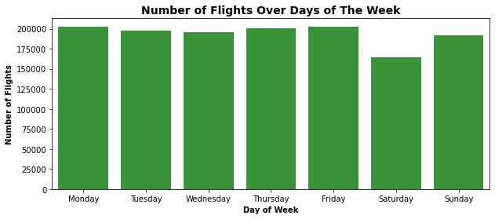

## Percentage of Flights For The Quarters

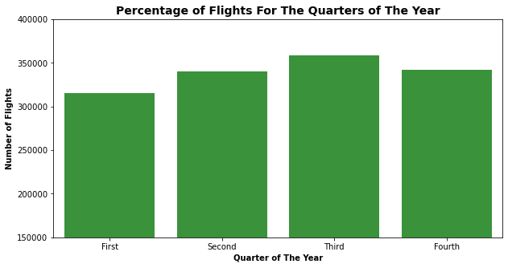

## Distribution of Day of Month

The last three days of the month have less air traffic all year round, while the remaining days are fairly constant.

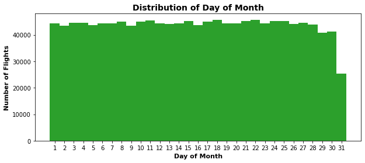

## Destination Cities of California Flights VS. Days of the Week

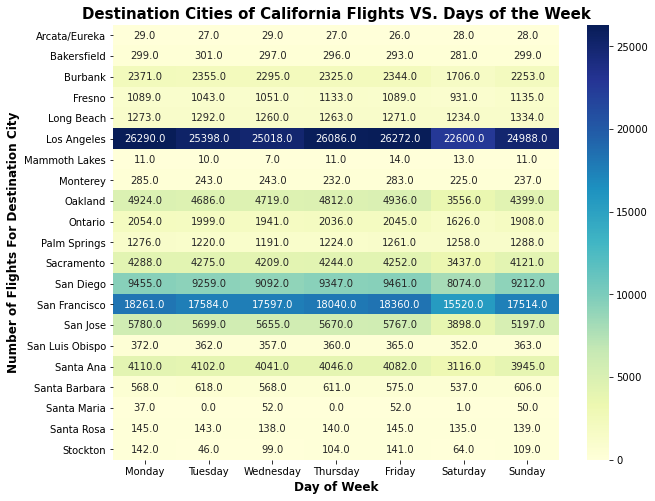

## Quarters of The Year VS. The Day of Week

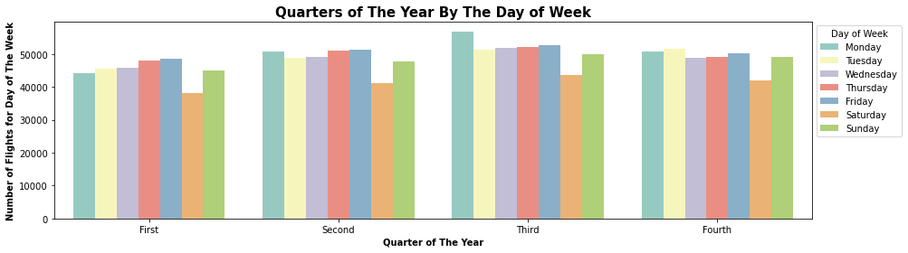

## Local Flights VS. The Quarters and Arrival Delay

For the first quarter, the city of Mammoth Lakes appears to have the highest average arrival delay for the destination city for local flights. The same was true for Bakersfield for the second and third quarters. And it seems that the city of San Luis Obispo has the highest average late arrival in the fourth quarter.

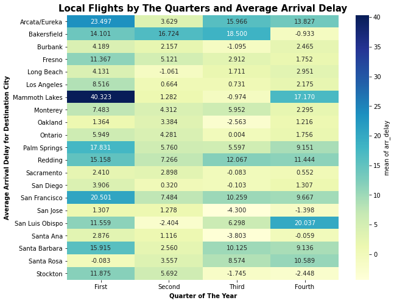